# 階層分群 (Hierarchical Clustering)

JianKai Wang (https://sophia.ddns.net/)

2018年4月10日

階層分群法透過階層架構方式，將資料層反覆地進行分裂與聚合，以產生最後的樹狀結構，常見方式有兩類：聚合方式與分裂方式。

- **聚合方式 (bottom-up, agglomerative)**

由樹狀結構的底部開始，將資料或分群逐次合併。起初將每一筆資料視成一個群聚 (cluster)，若有 n 筆資料，則可視成 n 個群聚，並依底下演算法形成聚合樹：

1. 將每筆資料視成一個群聚 $C_i, i = 1\ to\ n$
2. 找出所有群聚間，距離最近的兩個群聚 $C_i, C_j$
3. 合併 $C_i, C_j$ 成一個新的群聚
4. 若目前群聚數量大於設定的群聚數，則重複上述第 2-4 步驟，否則停止
- **分裂方式 (top-down, divisible)**

由樹狀結構的頂端開始，逐次分裂分群。起初將所有資料視成一個群聚 (cluster)，並依底下演算法形成分裂樹:

1. 將所有資料視成一個群聚 $C$，內包含 n 筆資料 $\{x_1, x_2, x_3, ... , x_n\}$
2. 找出所有的資料間，距離中心最遠的資料 $x_i$
3. 將此筆資料自群聚 $C$ 分裂出來並形成子群聚 $N$，剩餘群聚稱為 $C_m$
4. 計算剩餘群聚 $C_m$ 的每個資料點 $m$ 與本身群聚 $C_m$ 距離(記為 $d(c_m, m)$) 與 $N$ 距離(記為 $d(N,m)$)
5. 若 $d(c_m, m) > d(N,m)$，則將該資料點 $m$ 併入新群聚中
6. 若目前的群聚數量小於設定的群聚數，則重複上述第 2-5 步驟，否則停止

而因在實作上**聚合方式**較易實作，故底下亦以介紹聚合方式為主，在聚合時需定義兩個群聚的距離，底下有 4 種常用的群聚距離的定義：

- 單一連結演算法 (single-linkage algorithm): 群聚間的距離定義為不同群聚之最接近兩點資料間的距離

$$d(C_i, C_j) = min_{a \in C_i, b \in C_j}{d(a,b)}$$

- 完整連結演算法 (complete-linkage algorithm): 群聚間的距離定義為不同群聚之最遠兩點資料間的距離

$$d(C_i, C_j) = max_{a \in C_i, b \in C_j}{d(a,b)}$$

- 平均連結演算法 (average-linkage algorithm): 群聚間的距離定義為不同群聚各兩點資料間距離總和的平均 ($|C_i|$ 與 $|C_j|$ 表示資料個數)

$$d(C_i, C_j) = \sum_{a \in C_i, b \in C_j}{\frac{d(a,b)}{|C_i||C_j|}}$$

- 泛德法 (Ward’s method): 群聚間的距離定義為將兩群合併後，各點 $m$ 到合併後的新群聚中心的距離平方和 ($\mu$ 表示為新群聚的平均值)

$$d(C_i, C_j) = \sum_{a \in C_i, b \in C_j}{||m - \mu||}$$

## R 實作

### 安裝套件

```r
packageName <- c("stats")
for(i in 1:length(packageName)) {
  if(!(packageName[i] %in% rownames(installed.packages()))) {
    install.packages(packageName[i])
  }
}
lapply(packageName, require, character.only = TRUE)
```

```
## [[1]]
## [1] TRUE
```

### 產生資料

```r
set.seed(123)
getOriData <- matrix(c(
    dim1 = rnorm(30,mean=100,sd=5),
    dim2 = cos(rnorm(30,mean=200,sd=100)),
    dim3 = sin(rnorm(30,mean=500,sd=300)),
    dim4 = sample(c(-100:100,NA),size=30,replace=TRUE),
    dim5 = sample(c(500:1000,NA),size=30,replace=TRUE))
    , ncol = 5
)

# change name of matrix
colnames(getOriData) <- c("dim1","dim2","dim3","dim4","dim5")
rowNameList <- c()
for(i in 1:nrow(getOriData)) {
    rowNameList <- c(rowNameList,paste("data",toString(i),sep=""))
}
rownames(getOriData) <- rowNameList

# get rid of NAs
getOriData[is.na(getOriData)] <- 0

head(getOriData, 5)
```

```
##            dim1       dim2       dim3 dim4 dim5
## data1  97.19762 -0.7359092 -0.9583813   69  741
## data2  98.84911  0.6623476 -0.5531824  -37  626
## data3 107.79354  0.8841887 -0.8701556   43  608
## data4 100.35254  0.3500467 -0.3441745  -47  838
## data5 100.64644  0.8335847  0.5713495   20  523
```

### 建立 hclust 模型

```r
# the prototype of hclust
# d: 由函式 dist 產生的距離矩陣，或用 as.dist 來將矩陣轉換為距離矩陣
# method: 計算聚集的方法，如 average, complete, single, median, ... 等
hclust(d, method = "complete")

# the prototype of dist
# method: 距離計算方法，有 "euclidean", "maximum", "manhattan", "canberra", "binary", "minkowski" 等
dist(x. method="euclidean", ...)
```

底下利用歐幾里得距離來計算兩筆資料間的距離，亦可利用 Correlation 來計算兩筆資料間的相關性，並以此做為兩筆資料間的距離。透過函式 **hclust** 及方法 average 或 complete 來產生階層分群結果。

```r
# clustering based on correlation
getOriData.dist.cor <- as.dist(1 - cor(t(getOriData)))

# clustering based on euclidean
getOriData.dist.euc <- dist(getOriData)
hc_ave <- hclust(getOriData.dist.euc, "average")
hc_cmp <- hclust(getOriData.dist.euc, "complete")
summary(hc_ave)
```

```
##             Length Class  Mode
## merge       58     -none- numeric
## height      29     -none- numeric
## order       30     -none- numeric
## labels      30     -none- character
## method       1     -none- character
## call         3     -none- call
## dist.method  1     -none- character
```

### 分群結果

- 繪出階層分群結果

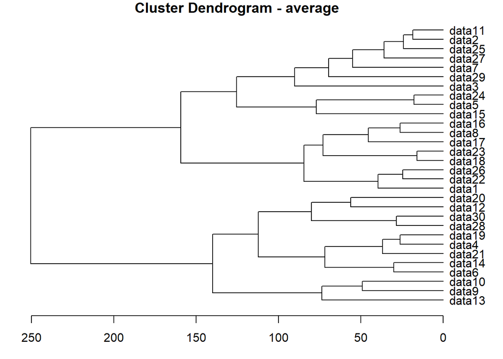

```r
# draw the dendrogram
par(mar=c(3,1,1,3))
plot(
     as.dendrogram(hc_ave), labels = NULL,
     axes = TRUE, frame.plot = FALSE, ann = TRUE,
     main = "Cluster Dendrogram - average",
     sub = NULL, cex = .6, horiz=T
)
```

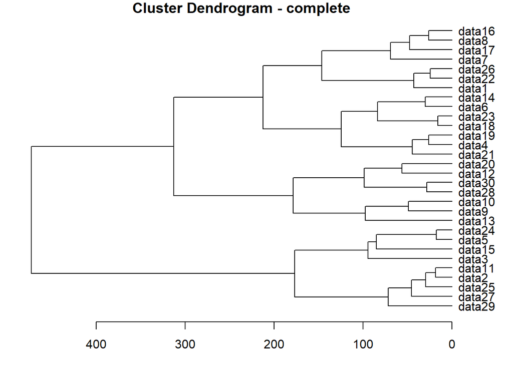

```r
par(mar=c(3,1,1,3))
plot(
     as.dendrogram(hc_cmp), labels = NULL,
     axes = TRUE, frame.plot = FALSE, ann = TRUE,
     main = "Cluster Dendrogram - complete",
     sub = NULL, cex = .6, horiz=T
)
```

- 列出各筆資料的高度

階層分群結束後，會如上圖的階層樹結果，可以透過屬性 **height** 來取得**資料合併時在階層樹中的高度(代表資料的差異距離)**，之後可以透過高度來分群。

```r
hc_ave$height
```

```
##  [1]  15.86985  17.69218  18.54191  24.14177  24.54019  26.13129  26.16949
##  [8]  28.33717  30.00059  35.96070  36.89931  39.65064  45.39283  49.07034
## [15]  55.03064  56.11457  69.47920  71.85406  73.06058  73.62122  77.13075
## [22]  79.92296  84.61022  90.20449 112.25442 125.47618 140.09498 159.39778
## [29] 250.41246
```

- 列出階層分群中子群集的聚合順序

可以透過屬性 **merge** 來取得資料聚合的順序。

```r
head(hc_ave$merge, 10)
```

```
##       [,1] [,2]
##  [1,]  -18  -23
##  [2,]   -5  -24
##  [3,]   -2  -11
##  [4,]  -25    3
##  [5,]  -22  -26
##  [6,]   -8  -16
##  [7,]   -4  -19
##  [8,]  -28  -30
##  [9,]   -6  -14
## [10,]  -27    4
```

由上可以看出第 1 次的聚合是第 18 筆(-18 標示)與第 23 筆(-23)資料，第 2 次的聚合是第 5 筆(-5)與第 24 筆(-24)資料，第 3 次的聚合是第 2 筆(-2)與第 11 筆(-11)資料，第 4 次的聚合是第 25 筆(-25)與第 3 次(+3 標示)合併後的資料，以此類推。

### 取得分群結果

- 透過分群數目來切樹

```r
# get sub-tree
# by how much groups generated
getSubtreeGroup <- cutree( hc_ave, k=15 )
getSubtreeGroup
```

```
##  data1  data2  data3  data4  data5  data6  data7  data8  data9 data10
##      1      2      3      4      5      6      2      7      8      8
## data11 data12 data13 data14 data15 data16 data17 data18 data19 data20
##      2      9     10      6     11      7      7     12      4     13
## data21 data22 data23 data24 data25 data26 data27 data28 data29 data30
##      4      1     12      5      2      1      2     14     15     14
```

- 透過高度來分群

```r
# by tree height
getSubtreeHeight <- cutree( hc_ave, h=100 )
getSubtreeHeight
```

```
##  data1  data2  data3  data4  data5  data6  data7  data8  data9 data10
##      1      2      2      3      4      3      2      1      5      5
## data11 data12 data13 data14 data15 data16 data17 data18 data19 data20
##      2      6      5      3      4      1      1      1      3      6
## data21 data22 data23 data24 data25 data26 data27 data28 data29 data30
##      3      1      1      4      2      1      2      6      2      6
```